# Statistical Inference Project2 - Tooth Data

Diane Clow

August 22, 2015

#### Introduction

This is the Second Course Project for Statistical Inference. The assignment asks students to analyse the data in the ToothGrowth dataset in R and run some analysis.

To complete this assignment I will:

#### Exploratory Analysis

```r
library(ggplot2)
data(ToothGrowth)
head(ToothGrowth)
```

```
##    len supp dose
## 1  4.2   VC  0.5
## 2 11.5   VC  0.5
## 3  7.3   VC  0.5
## 4  5.8   VC  0.5
## 5  6.4   VC  0.5
## 6 10.0   VC  0.5
```

The three variables in this data set are: len - numeric, the length of the tooth, supp - factor, the supplement type (VC or OJ), dose - numeric, dose in milligrams/day. VC is ascorbic acid, a form of vitamin C and OJ stands for Orange Juice.

The following graph shows box plots broken up by supplement and dose.

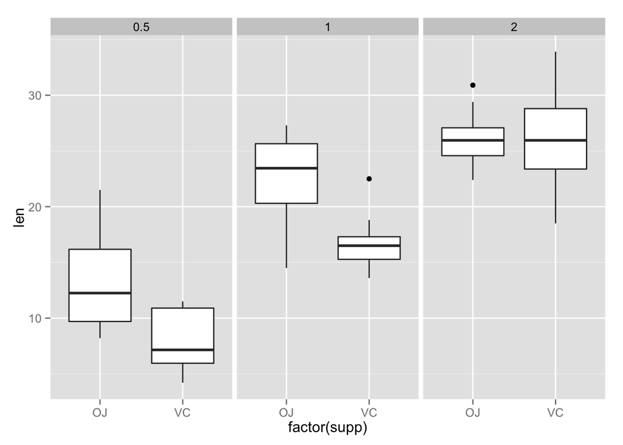

```r
ggplot(ToothGrowth, aes(factor(supp), len)) + geom_boxplot() + facet_grid(. ~ dose)
```

#### Basis Summary

Shown below is the summary information for the data set ToothGrowth. Below that is the data aggregrated for mean and standard deviation on both supp and dose.

```r
summary(ToothGrowth)
```

```
##       len        supp         dose
##  Min.   : 4.20   OJ:30   Min.   :0.500
##  1st Qu.:13.07   VC:30   1st Qu.:0.500
##  Median :19.25           Median :1.000
##  Mean   :18.81           Mean   :1.167
##  3rd Qu.:25.27           3rd Qu.:2.000
##  Max.   :33.90           Max.   :2.000
```

```r
aggregate(ToothGrowth$len, by=list(ToothGrowth$supp, ToothGrowth$dose), FUN=mean)
```

```
##   Group.1 Group.2     x
## 1      OJ     0.5 13.23
## 2      VC     0.5  7.98
## 3      OJ     1.0 22.70
## 4      VC     1.0 16.77
## 5      OJ     2.0 26.06
## 6      VC     2.0 26.14
```

```r
aggregate(ToothGrowth$len, by=list(ToothGrowth$supp, ToothGrowth$dose), FUN=sd)
```

```
##   Group.1 Group.2        x
## 1      OJ     0.5 4.459709
## 2      VC     0.5 2.746634
## 3      OJ     1.0 3.910953
## 4      VC     1.0 2.515309
## 5      OJ     2.0 2.655058
## 6      VC     2.0 4.797731
```

#### Comparison

```r
OJ0.5 <- subset(ToothGrowth, supp == "OJ" & dose == 0.5)
VC0.5 <- subset(ToothGrowth, supp == "VC" & dose == 0.5)
OJ1 <- subset(ToothGrowth, supp == "OJ" & dose == 1)
VC1 <- subset(ToothGrowth, supp == "VC" & dose == 1)
OJ2 <- subset(ToothGrowth, supp == "OJ" & dose == 2)
VC2 <- subset(ToothGrowth, supp == "VC" & dose == 2)
```

For each dose size a t-test will be preformed. For all these test, I will be testing if the length with OJ is the same as the length with VC. If the lengths are the same, I will accept my null hypothosis and 0 will be within the confidence interval. If 0 is not within the confidence interval, the alternate hypothosis will be accepted, that OJ has a greater impact on teeth length. The confidance level for the following tests is 0.95. This means that there is a 5% chance they will produce false results.

H_0 <- Both supplements have the same impact

H_a <- OJ has a larger impact that VC

Sig <- .95

```r
t.test(OJ0.5$len - VC0.5$len, paired = FALSE, var.equal = FALSE)
```

```
##
##  One Sample t-test
##
## data:  OJ0.5$len - VC0.5$len
## t = 2.9791, df = 9, p-value = 0.01547
## alternative hypothesis: true mean is not equal to 0
## 95 percent confidence interval:
##  1.263458 9.236542
## sample estimates:
## mean of x
##      5.25
```

```r
t.test(OJ1$len - VC1$len, paired = FALSE, var.equal = FALSE)
```

```
##
##  One Sample t-test
##
## data:  OJ1$len - VC1$len
## t = 3.3721, df = 9, p-value = 0.008229
## alternative hypothesis: true mean is not equal to 0
## 95 percent confidence interval:
##  1.951911 9.908089
## sample estimates:
## mean of x
##      5.93
```

```r
t.test(OJ2$len - VC2$len, paired = FALSE, var.equal = FALSE)
```

```
##
##  One Sample t-test
##
## data:  OJ2$len - VC2$len
## t = -0.0426, df = 9, p-value = 0.967
## alternative hypothesis: true mean is not equal to 0
## 95 percent confidence interval:
##  -4.328976  4.168976
## sample estimates:
## mean of x
##     -0.08
```

#### Conclusion

As shown in the tests above only with the dosage = 2, is the difference between OJ and VC statistically insignificant. For both of the lower dosages, OJ has an impact on the length.